# Probability and Distributions in R

# Related Distributions

## The Normal Distribution

We’ve been exploring the binomial distribution, the result of flipping multiple coins multiple times and calculating the number of heads. In this chapter, we’re going to introduce three other important probability distributions and see how they each connect to the theme of flipping coins. You will not only add these distributions to your statistical tool box, but also see how the principles we’ve learned about working with random variables and simulation are important far beyond the binomial.

So far, you’ve often looked at a binomial where each draws made up of 10 flips of a coin has a 50% chance of heads. That will look like this distribution: a histogram where the most common value is 5.

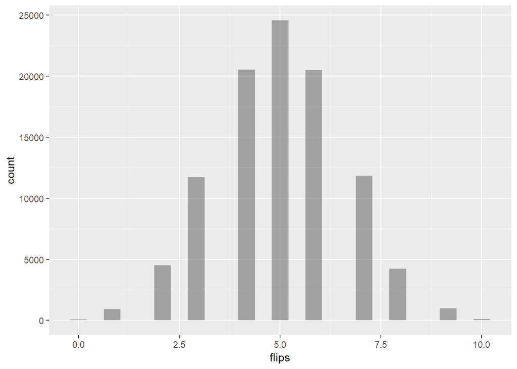

```r
gf_histogram( ~ rbinom(100000, 10, .5), xlab = "flips")
```

Now imagine instead of flipping 10 or 20 fair coins in each draw we flipped 1000. Now the distribution of the number of heads is centered around 500. Notice the distribution is now taking on a sort of symmetrical, bell curve shape. This is because when you draw from the binomial with a very large size i.e. many coin flips, the results approximates a **normal distribution**. Approximations from one distribution to another are important in probability since they let you make connections between statistical tools.

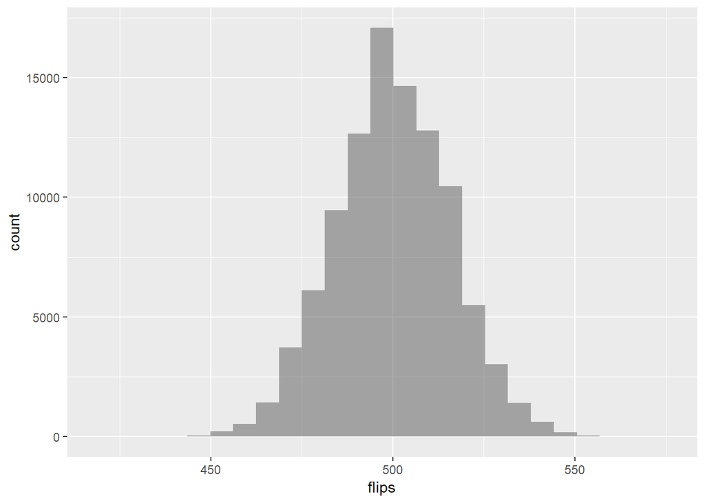

```r
gf_histogram( ~ rbinom(100000, 1000, .5), xlab = "flips")
```

You’ll sometimes hear a normal distribution referred to as a **gaussian distribution** or a **bell curve**. It’s famous because many distributions in nature take this shape such as measurement errors in scientific experiments and because its mathematical properties are well-understood. Many of the courses on the datacamp platform show how the normal distribution can be used in statistical inference. While the binomial is defined in terms of parameters $size$ i.e. number of flips and $p$, the probability of heads, the normal distribution is defined based on two other parameters: the mean ($\mu$) and the standard deviation ($\sigma$).

Mathematically, we usually represent the mean as the Greek letter ($\mu$) and standard deviation as the Greek letter ($\sigma$).

$$X \sim Normal(\mu, \sigma)$$

In chapters 1 and 2, we introduced the concept of variance i.e. the average square distance from the mean. The standard deviation is square root of the variance.

$$\sigma = \sqrt{Var(X)}$$

While `R` defines the normal distribution using the standard deviation, some statisticians choose to define it using the variance. It’s not that important what you choose because if you know one you know the other. You can square the standard deviation to get the variance or take square root of the varianc to get the standard deviation. Because the normal is defined in terms of the mean and standard deviation, it’s easy to find the normal approximation to a particular binomial distribution. For example, we could a sample of a 100,000 draws in a binomial distribution with size 1000 and probability 0.5.

```r
binomial_flips <- rbinom(100000, 1000, 0.5)
```

$$\mu = size \cdot p$$

$$\sigma = \sqrt{size \cdot p \cdot (1 - p)}$$

```r
expected_value <- 1000 * 0.5
variance <- 1000 * 0.5 * (1 - 0.5)
stdev <- sqrt(variance)
```

We can then simulate from the normal using this parameters. We do this with the `rnorm()` function rather than `rbinom()`. The first argument is the number of draws, the second is the mean i.e. the same as the expected value of the binomial, and the third is the standard deviation.

```r
normal <- rnorm(100000, expected_value, stdev)
```

Now, that we’ve simulated 100,000 draws from the binomial and from the corresponding normal distribution, we’ll like to compare them to see if the normal really is a good approximation. Both of the plots look similar confirming that the normal distribution is a good approximation of the the binomial.

```r
binomial_draws <- data.frame(draws = rbinom(100000, 1000, 0.5))
normal_draws <- data.frame(draws = rnorm(100000, expected_value, stdev))

binomial_draws$type <- 'binomial'
normal_draws$type <- 'normal'

prob_dist <- rbind(binomial_draws, normal_draws)

head(prob_dist)
```

```
#>   draws     type
#> 1   493 binomial
#> 2   500 binomial
#> 3   507 binomial
#> 4   483 binomial
#> 5   500 binomial
#> 6   494 binomial
```

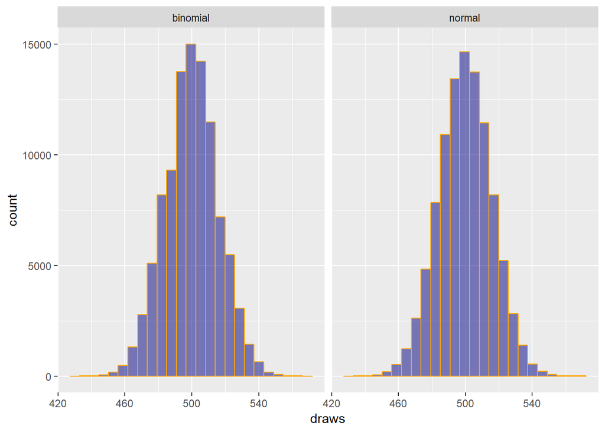

```r
gf_histogram( ~ draws, data = prob_dist, size = 0.5, color = "orange", fill = "navy blue") %>% gf_facet_wrap(~ type)
```

## Simulating from the binomial and the normal

In this exercise you’ll see for yourself whether the normal is a reasonable approximation to the binomial by simulating large samples from the binomial distribution and its normal approximation and comparing their histograms.

```r
# compare_histogram <- function(variable1, variable2) {
#   x <- data.frame(value = variable1, variable = "Variable 1")
#   y <- data.frame(value = variable2, variable = "Variable 2")
#   ggplot(rbind(x, y), aes(value)) +
#     geom_histogram() +
#     facet_wrap(~ variable, nrow = 2)
# }
```

```r
compare_histograms <- function(variable1, variable2) {
  x <- data.frame(value = variable1, variable = "Variable 1")
  y <- data.frame(value = variable2, variable = "Variable 2")
    rbind(x, y) %>%
    ggformula::gf_histogram(~ value) %>%
    gf_facet_wrap(~ variable, nrow = 2)
}
```

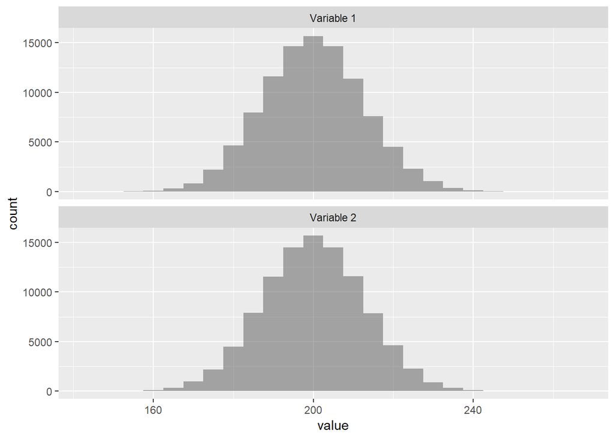

```r
# Draw a random sample of 100,000 from the Binomial(1000, .2) distribution
binom_sample <- rbinom(100000, 1000, 0.2)

# Draw a random sample of 100,000 from the normal approximation
normal_sample <- rnorm(100000, 200, sqrt(var(binom_sample)))

# Compare the two distributions with the compare_histograms function
compare_histograms(binom_sample, normal_sample)
```

## Comparing the cumulative density of the binomial

If you flip 1000 coins that each have a 20% chance of being heads, what is the probability you would get 190 heads or fewer?

You’ll get similar answers if you solve this with the binomial or its normal approximation. In this exercise, you’ll solve it both ways, using both simulation and exact calculation.

```r
# Simulations from the normal and binomial distributions
binom_sample <- rbinom(100000, 1000, .2)
normal_sample <- rnorm(100000, 200, sqrt(160))

# Use binom_sample to estimate the probability of <= 190 heads
mean(binom_sample <= 190)
```

```
#> [1] 0.22883
```

```r
# Use normal_sample to estimate the probability of <= 190 heads
mean(normal_sample <= 190)
```

```
#> [1] 0.2159
```

```r
# Calculate the probability of <= 190 heads with pbinom
pbinom(190, 1000, 0.2)
```

```
#> [1] 0.2273564
```

```r
# Calculate the probability of <= 190 heads with pnorm
pnorm(190, 200, sqrt(160))
```

```
#> [1] 0.2145977
```

Great job! There are a lot of different ways to go about getting similar answers.

## Comparing the distributions of the normal and binomial for low n

When we flip a lot of coins, it looks like the normal distribution is a pretty close approximation. What about when we flip only 10 coins, each still having a 20% chance of coming up heads? Is the normal still a good approximation?

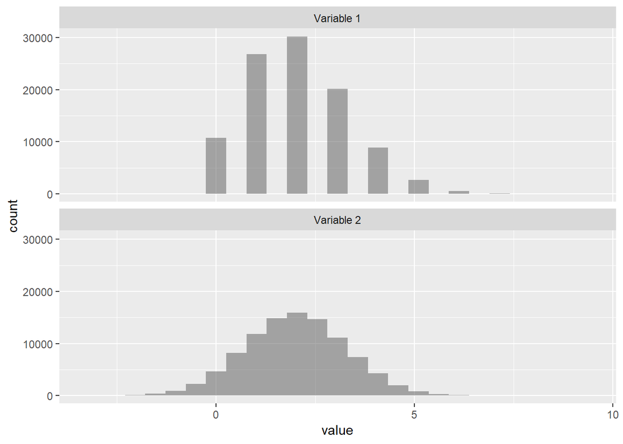

```r
# Draw a random sample of 100,000 from the Binomial(10, .2) distribution
binom_sample <- rbinom(100000, 10, 0.2)

# Draw a random sample of 100,000 from the normal approximation
normal_sample <- rnorm(100000, 2, sqrt(1.6))

# Compare the two distributions with the compare_histograms function
compare_histograms(binom_sample, normal_sample)
```

Good work! How do the sample size and the probability of success effect the accuracy of the normal approximation?

- Answer: We need a larger sample size in order for the normal distribution to approximate the binomial distribution.

## The Poisson Distribution

In the last lesson we tried flipping a very large number of coins and we noticed the resulting number of heads could be approximately by a normal distribution. In this lesson we’ll introduce another distribution that is related to the binomial, the poisson distribution. Suppose we flip 1000 coins but this time every coin has only a 1 / 1000 probability of being heads. We are considering *how often a rare event happens out of a large number of opportunities*. We can simulate this with the `rbinom()` function by setting the second parameter to a 1000 and the third to be 1 / 1000.

```r
binomial_flips <- rbinom(100000, 1000, 1 / 1000)
```

The histogram will look like this:

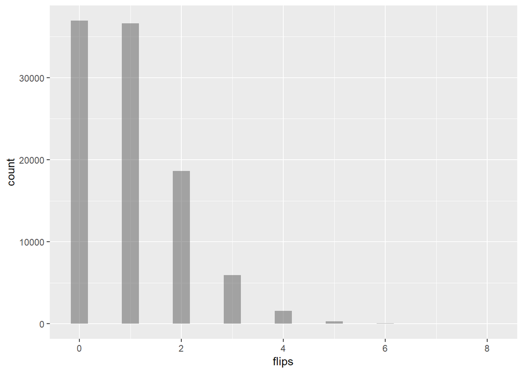

```r
gf_histogram( ~ binomial_flips, xlab = "flips")
```

Notice that unlike the last exercise this distribution doesn’t look like a bell curve at all. For one thing it’s not symmetrical because the number of heads can’t be smaller than zero. This particular case of the binomial where n is large and p is small can be approximated by the poisson distribution.

## Properties of the Poisson Distribution

The binomial distribution required two parameters to define it: size or number of flips and p, the probability that a fair coin will result in heads. The poisson distribution is simple because it is described by only one parameter, the mean, which for poisson we usually call by the Greek letter ($\lambda$).

$$X \sim \textrm{Poisson}(\lambda) \\ E[X] = \lambda$$

The mean of the binomial with 1000 flips and 1 / 1000 for each is simply 1. So to simulate the corresponding poisson we’ll use the `rpois()` function. After the argument 100000, we give the parameter, 1.

```r
poisson_sample <- rpois(100000, 1)
```

We can see from our `compare_histograms()` function that these distributions are similar. This means for this distribution we don’t need the extra detail that is out of a 1000 coin; we just need the mean.

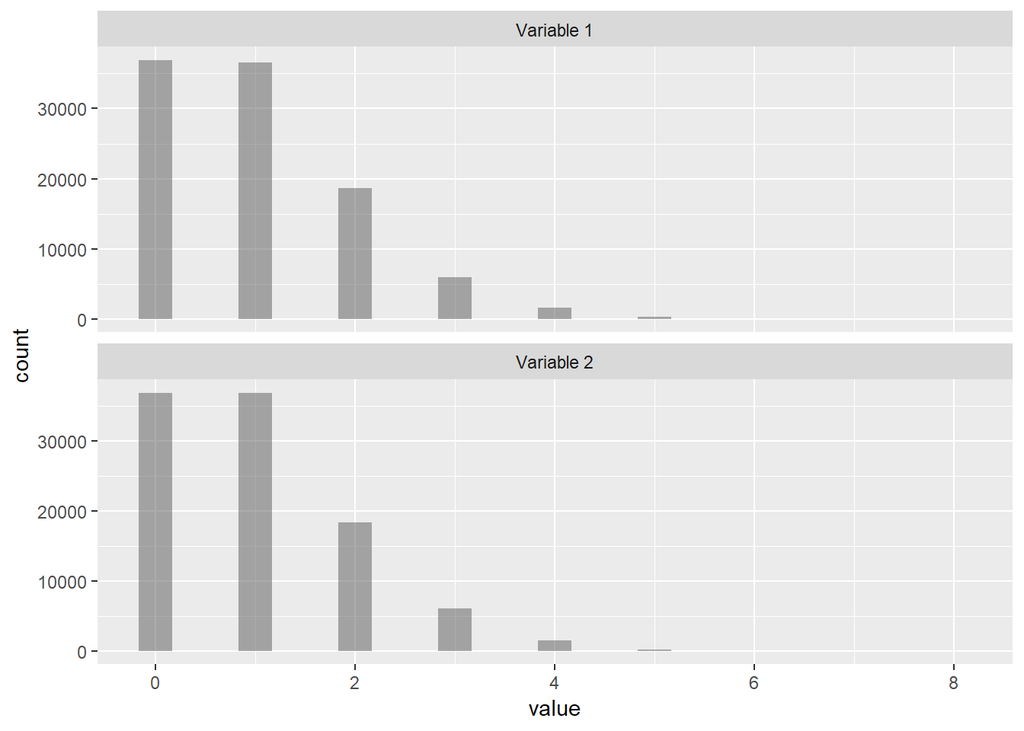

```r
compare_histograms(binomial_flips, poisson_sample)
```

One interesting fact about the poisson distribution is that its variance is equal to the mean. This makes it convenient to work with since you don’t need to calculate the variance when you are simulating or estimating it.

$$\textrm{Var}(X) = \lambda$$

The poisson distribution can have any mean as long as it is positive. It could have one very close to zero like 0.1 in which case most of the outcomes will be 0 or 1. It could have a larger value like 10 in which case it will be more symmetrical.

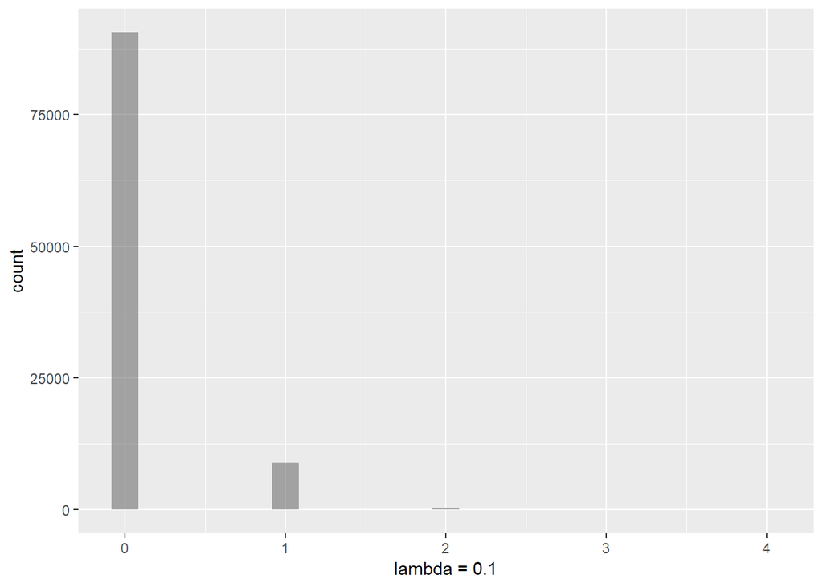

```r
gf_histogram(~ rpois(100000, 0.1), xlab = "lambda = 0.1")
```

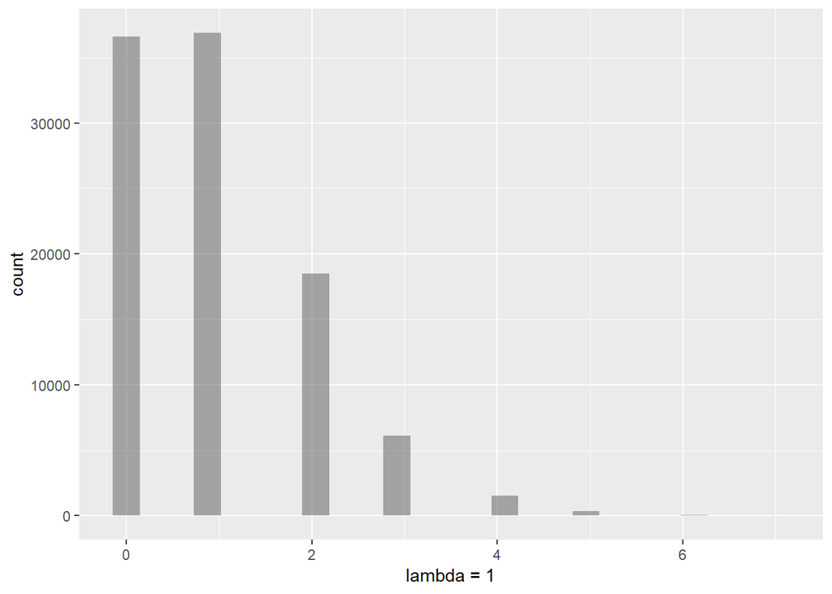

```r
gf_histogram(~ rpois(100000, 1), xlab = "lambda = 1")
```

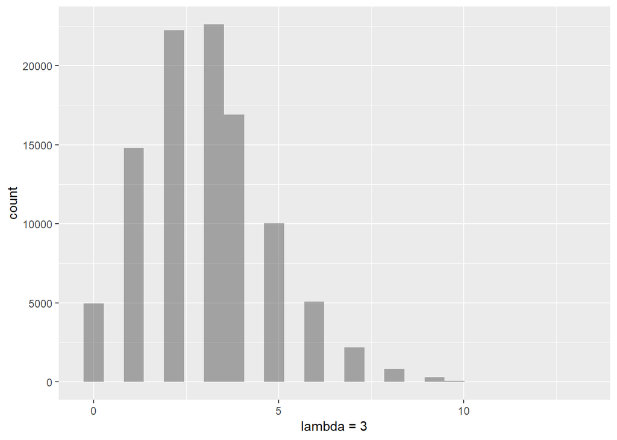

```r
gf_histogram(~ rpois(100000, 3), xlab = "lambda = 3")
```

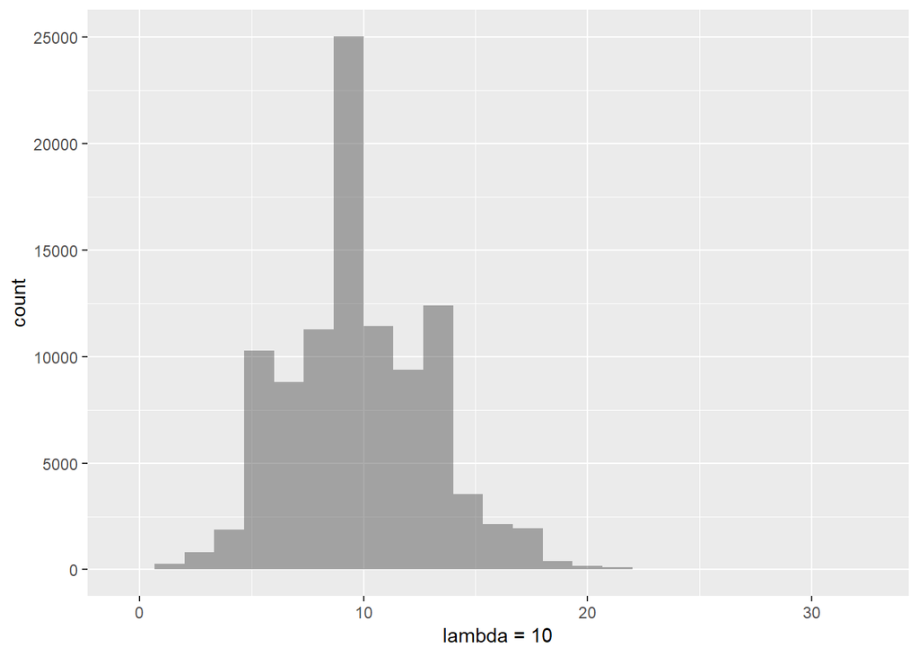

```r
gf_histogram(~ rpois(100000, 10), xlab = "lambda = 10")
```

Statisticians and scientists use the poisson distribution when they are modelling rare events and counts, and when they don’t care about the total in the way we would with the binomial distribution. For example, you could be running a book store and modelling how many walk in each hour; you could be counting whales within the section of the ocean on one day; or counting cells under a microscope. In one sense each of this is technically a fraction of the total (a percentage of the people, whale, or cells), but you wouldn’t think of it that way. You don’t care about the probability of seeing it everywhere in the world; you care about the number that you see.

## Simulating from a poisson and a binomial

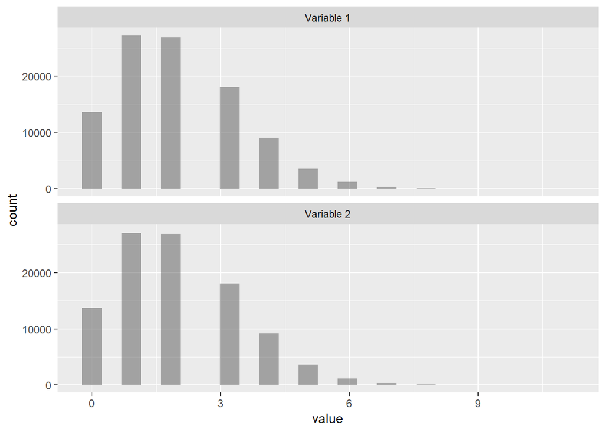

```r
# Draw a random sample of 100,000 from the Binomial(1000, .002) distribution
binom_sample <- rbinom(100000, 1000, .002)

# Draw a random sample of 100,000 from the Poisson approximation
poisson_sample <- rpois(100000, 2)

# Compare the two distributions with the compare_histograms function
compare_histograms(binom_sample, poisson_sample)
```

Fantastic! It’s interesting how the binomial distribution is related to so many others.

## Density of the Poisson distribution

In this exercise you’ll find the probability that a Poisson random variable will be equal to zero by simulating and using the dpois() function, which gives an exact answer.

```r
# Simulate 100,000 draws from Poisson(2)
poisson_sample <- rpois(100000, 2)

# Find the percentage of simulated values that are 0
mean(poisson_sample == 0)
```

```
#> [1] 0.13419
```

```r
# Use dpois to find the exact probability that a draw is 0
dpois(0, 2)
```

```
#> [1] 0.1353353
```

Great work! You’re a real density pro by now!

## Sum of two Poisson variables

One of the useful properties of the Poisson distribution is that when you add multiple Poisson distributions together, the result is also a Poisson distribution.

Here you’ll generate two random Poisson variables to test this.

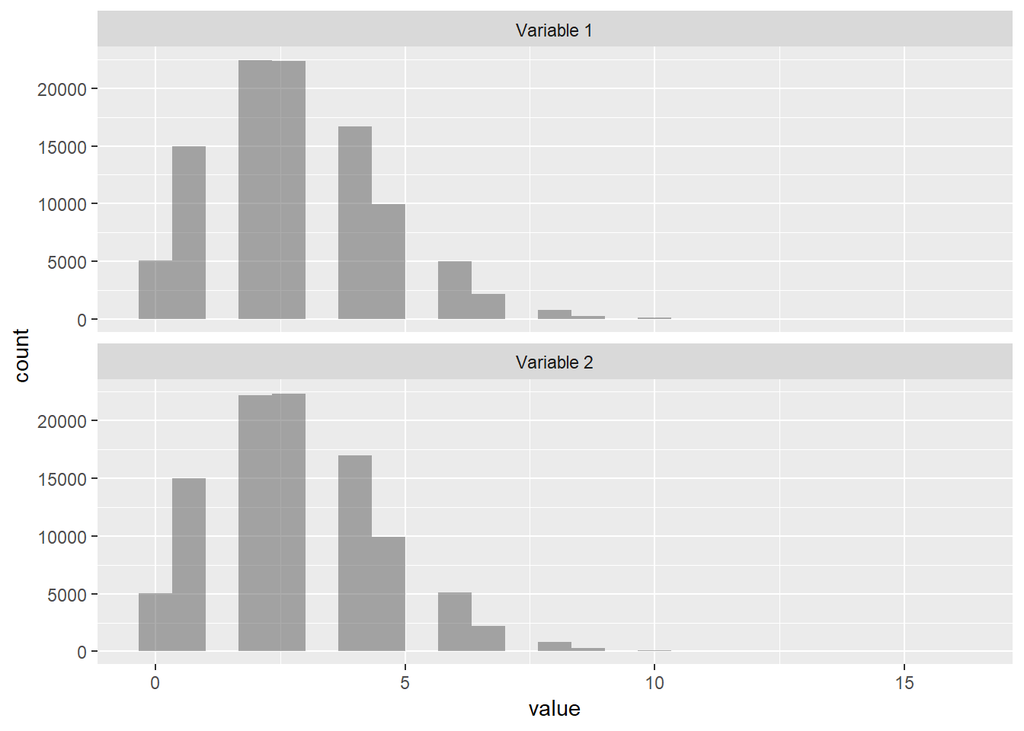

```r
# Simulate 100,000 draws from Poisson(1)
X <- rpois(100000, 1)

# Simulate 100,000 draws from Poisson(2)
Y <- rpois(100000, 2)

# Add X and Y together to create Z
Z <- X + Y

# Use compare_histograms to compare Z to the Poisson(3)
compare_histograms(Z, rpois(100000, 3))
```

## The Geometric Distribution

Suppose this coin I’m holding has a 10% chance of coming up heads. Now, instead of flipping it a fix number of times I keep flipping it until the first time I see heads. How many tails do you think I’ll get before the first time I get heads? I could heads in the first try so it could be zero or I could be standing here flipping a coin all day. What can I expect? This random variable when you are waiting for a particular event with some probability is called the geometric distribution and it’s the last one we’ll explore in this course.

## Simulating waiting for heads

One way to simulate waiting for a result of heads is to flip a large number of coins and see what the first of heads is. For example with `rbinom(100, 1, .1)` we can simulate flipping 100 coins each with a 10% probability of heads in sequence. In this case we are only showing the first 30 and we can see that 5 of the first 30 results in heads and the results were tails.

```r
flips <- rbinom(100, 1, 0.1)
flips[1:30]
```

```
#>  [1] 0 1 0 0 0 0 1 0 0 1 0 0 0 0 0 0 0 1 0 0 0 1 0 0 0 0 0 0 0 0
```

If we don;t want to count the coins manually we can use the `which()` function. `which()` returns the indices that fit a particular condition. For example, with `which(flips == 1)` we can find out which coin sequence were heads. In this case, we see that the first heads was the 2<sup>nd</sup> flip.

```r
which(flips == 1)
```

```
#>  [1]  2  7 10 18 22 37 46 61 67 71 84 98
```

Since, we are only interested in the first heads let’s use `which(flips == 1)[1]` to extract the first item. This code therefore gave us one draw from this random variable.

```r
which(flips == 1)[1]
```

```
#> [1] 2
```

## Replicating simulations

```r
# set.seed(43)
which(rbinom(100, 1, 0.1) == 1)[1]
```

```
#> [1] 20
```

```r
which(rbinom(100, 1, 0.1) == 1)[1]
```

```
#> [1] 2
```

```r
which(rbinom(100, 1, 0.1) == 1)[1]
```

```
#> [1] 1
```

It’s a hassle to keep writing the same line of code to perform the same draws so `R` makes it easy with a `replicate()` function. `replicate()` takes two arguments:

1. `n` = the number of replications to perform
2. `expr` = the expression containing the line of code (you can just paste it directly in).

```r
replicate(10, which(rbinom(100, 1, 0.1) == 1)[1])
```

```
#>  [1]  8  6  5 17  3 15  7  5 11 12
```

This is the **geometric** distribution. It’s useful for modeling situations where for example a machine has a 10% chance of breaking each day and you want to know how long it will last before it breaks. As you see such a machine might last for weeks or it might break in just the first day.

## Simulating with the `rgeom()` function

It’s worth understanding of how you can generate a distribution like this with the `replicate()` function since been flexible with simulations is important in probability, but in this case `R` does provide a shortcut: the `rgeom()` function. You give it the number of draws and the probability of the event you are waiting for in this case, 0.1. Notice that the distribution is steadily decreasing in density: every possible value is less likely than the previous one. The most likely value is therefore 0, meaning that, in this case, there were no tails before the first heads.

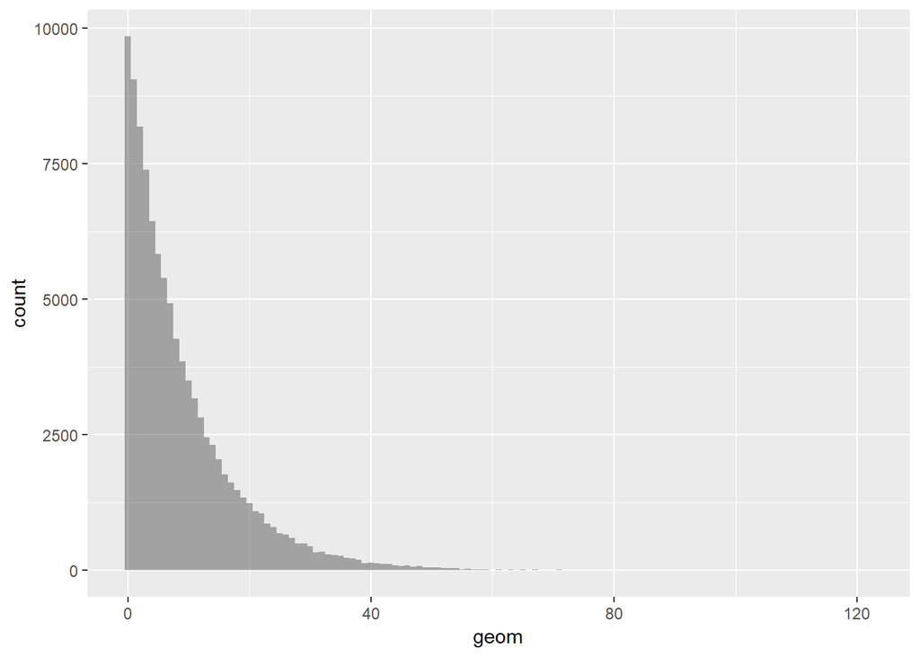

simulating a geometric distribution

```r
gf_histogram( ~ rgeom(100000, 0.1), xlab = "geom", binwidth = 1)
```

What’s the expected value or the mean of this distribution? We can estimate it with `mean()` and see that it is about 9 i.e. when each coin has a 10% chance of heads, the first heads will, on average, be the 10<sup>th</sup>.

```r
mean(rgeom(100000, 0.1))
```

```
#> [1] 9.00343
```

The general rule of the expected value is 1 divided by the probability minus 1. The minus 1 comes from the fact that `R` defines the geometric distribution has the number of tails before the first heads. If we define it just as the first heads, it will be simply 1 / p. This means for example if each coin has a 50% chance of resulting in heads, the expected value will be 1. On average, you will see 1 tails before the first heads.

$$X \sim \textrm{Geom}(p)\\ E[X] = \frac{1}{p} - 1$$

## Waiting for the first coin flip

```r
# Simulate 100 instances of flipping a 20% coin
flips <- rbinom(100, 1, 0.2)

# Use which to find the first case of 1 ("heads")
which(flips == 1)[1]
```

```
#> [1] 1
```

Wow! What situations can you think of that are good examples of a geometric distribution?

- If a machine has a 10% chance of failure a day, how long will it before we experience the first failure?

```r
# Existing code for finding the first instance of heads
which(rbinom(100, 1, 0.2) == 1)[1]
```

```
#> [1] 15
```

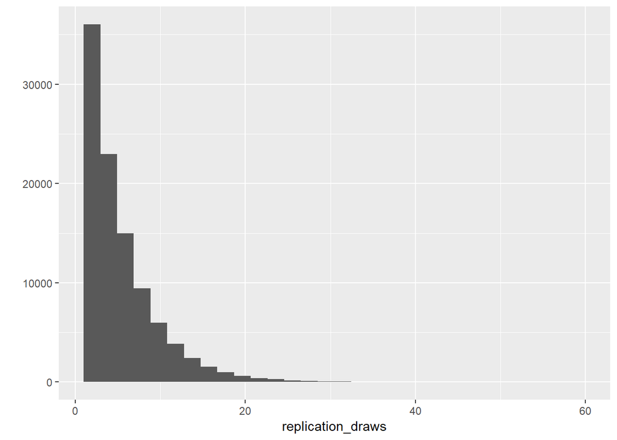

```r
# Replicate this 100,000 times using replicate()
replication_draws <- replicate(100000, which(rbinom(100, 1, 0.2) == 1)[1])

# Histogram the replications with qplot
qplot(replication_draws)
```

## Simulating from the geometric distribution

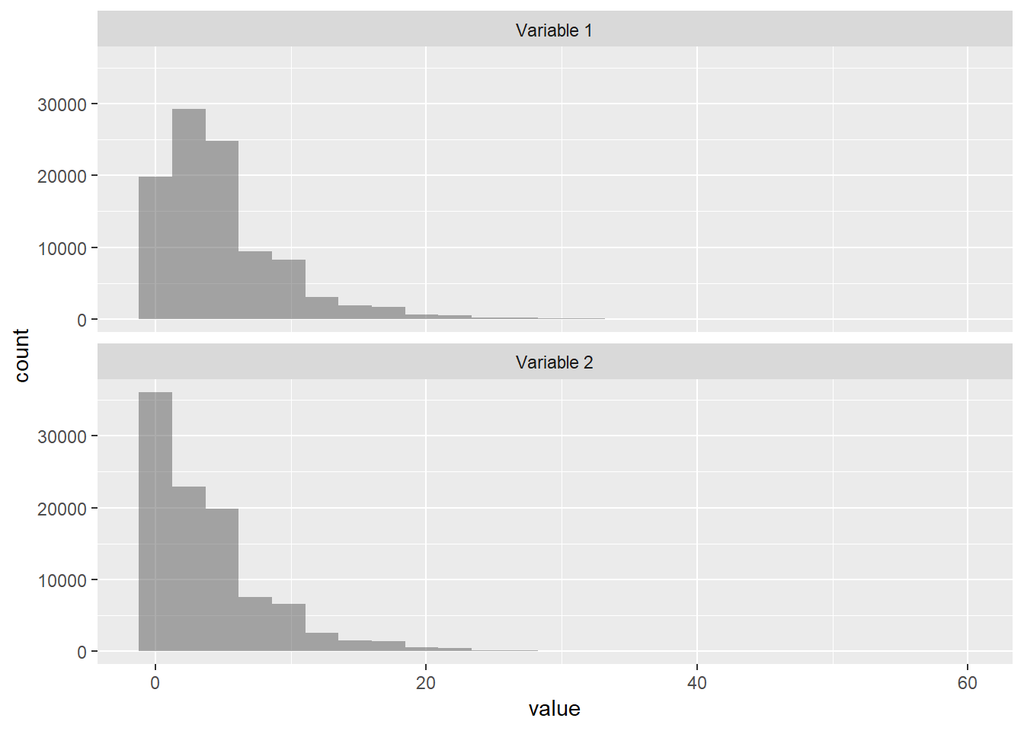

```r
# Replications from the last exercise
replication_draws <- replicate(100000, which(rbinom(100, 1, .2) == 1)[1])

# Generate 100,000 draws from the corresponding geometric distribution
geom_sample <- rgeom(100000, 0.2)

# Compare the two distributions with compare_histograms
compare_histograms(replication_draws, geom_sample)
```

Fantastic simulating! And the rgeom() function is definitely easier to type than using rbinom() to simulate a geometric distribution.

## Probability of machine lasting X days

A new machine arrives in a factory. This type of machine is very unreliable: every day, it has a 10% chance of breaking permanently. How long would you expect it to last?

Notice that this is described by the cumulative distribution of the geometric distribution, and therefore the `pgeom()` function. `pgeom(X, .1)` would describe the probability that there are X working days before the day it breaks (that is, that it breaks on day X + 1).

```r
# Find the probability the machine breaks on 5th day or earlier
pgeom(4, 0.1)
```

```
#> [1] 0.40951
```

```r
# Find the probability the machine is still working on 20th day
1 - pgeom(19, 0.1)
```

```
#> [1] 0.1215767
```

## Graphing the probability that a machine still works

If you were a supervisor at the factory with the unreliable machine, you might want to understand how likely the machine is to keep working over time. In this exercise, you’ll plot the probability that the machine is still working across the first 30 days.

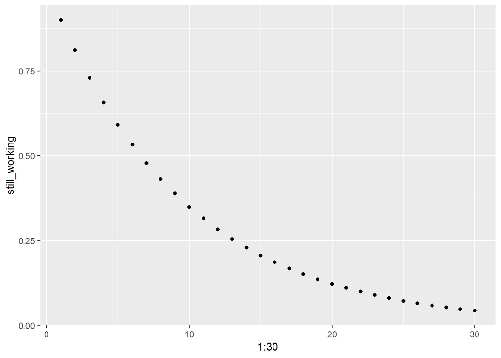

```r
# Calculate the probability of machine working on day 1-30
still_working <- 1 - pgeom(0:29, 0.1)

# Plot the probability for days 1 to 30
qplot(1:30, still_working)
```

Great work! You’ve learned all the basics you need to start understanding the distributions underlying statistical models!